# The Short-Time Fourier Transform

## Chris Tralie

Below are some notes about what we went over in class. We start by defining a method to compute the cosine and sine amplitudes for the DFT frequencies

```python
import numpy as np
import matplotlib.pyplot as plt
import librosa
import IPython.display as ipd

def get_dft(x):
    """
    Return the non-redundant real/imaginary components
    of the DFT, expressed as amplitudes of sines/cosines
    involved

    Parameters
    ----------
    x: ndarray(N)
        A signal

    Returns
    -------
    cos_sum: ndarray(ceil(N/2)), sin_sums(ndarray(ceil(N/2)))
        DFT cosine/sine amplitudes
    """
    N = len(x)
    t = np.linspace(0, 1, N+1)[0:N]
    n_freqs = int(np.ceil(N/2))
    f = np.fft.fft(x)
    cos_sums = np.real(f)[0:n_freqs]/(N/2)
    sin_sums = -np.imag(f)[0:n_freqs]/(N/2)
    return cos_sums, sin_sums
```

Now, we load in an audio file of Prof. Tralie playing a chromatic scale on the violin, going through all 24 halfsteps over two octaves in order

```python
x, sr = librosa.load("chromatic2octaves.wav")
ipd.Audio(x, rate=sr)
```

[interactive chart not shown]

When we look at the DFT amplitudes, however, everything gets blurred together, because there are many notes that happen at different times, so it's not easy to pick out any single note

[interactive chart not shown]

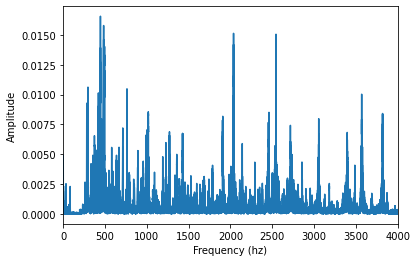

```python
x, sr = librosa.load("chromatic2octaves.wav")
N = len(x)
c, s = get_dft(x)
amps = np.sqrt(c**2 + s**2)
freqs = np.arange(len(c))*sr/len(x)
plt.plot(freqs, amps)
plt.xlabel("Frequency (hz)")
plt.ylabel("Amplitude")
plt.xlim([0, 4000])
ipd.Audio(x, rate=sr)
```

### Short-Time Fourier Transform

What we need is something where we compute the DFT on small chunks of audio so we can hone in on regions where the frequencies aren't changing too much. What this leads to is the notion of the *Short-Time Fourier Transform*, where we perform many DFTs on small chunks of audio. There are two parameteres that go into the STFT:

- The window length, which is the length of a chunk of audio in samples that's processed
- The hop length, which is the number of samples between windows as we jump from one to the next

[figure not shown]

Let's define a method that does this. We note that for audio with $N$ samples and an STFT with window length $w$ and hop length $h$, the number of windows is

### $floor((N - w)/h) + 1$

We also define a special version of the STFT where we look at the amplitude only (no phase), which is referred to as a *spectrogram*

```python
def specgram(x, w, h, sr):
    """
    Compute the "spectrogram"
    (amplitudes of the short-time fourier transfrom)
    Parameters
    ----------
    x: ndarray(N)
        Full audio clip of N samples
    w: int
        Window length
    h: int
        Hop length
    sr: int
        Sample rate

    Returns
    -------
    ndarray(w, nwindows) Spectrogram
    """
    N = len(x)
    i = 0
    nwin = int(np.floor((N-w)/h))+1
    n_freqs = int(np.ceil(w/2))
    # Make a 2D array
    # The rows correspond to frequency bins
    # The columns correspond to windows moved forward in time
    S = np.zeros((n_freqs, nwin))
    # Loop through all of the windows, and put the fourier
    # transform amplitudes of each window in its own column
    for j in range(nwin):
        # Pull out the audio in the jth window
        # Ex) First window x[0:w]
        # Ex) Second window x[h:h+w]
        # Ex) Third window x[2h:2h+w]
        xj = x[h*j:h*j+w]
        # Do the fourier transform of the jth window
        c, s = get_dft(xj)
        amps = np.sqrt(c**2 + s**2)
        # Put the fourier transform amplitudes into S
        S[:, j] = amps
    return S
```

### Time vs Frequency Resolution Tradeoff

There is, however, a tradeoff in the time and frequency resolution. If we want to really hone in on exactly where notes are happening in time, it means we need to choose a small window. But we only have half as many samples in frequency as there are samples in the window to spread out between $0hz$ and $sr/2$ hz, so that means we will have a low frequency resolution. By contrast, if we take large windows, then we have a lot more frequencies to spread out between $0$ and $sr/2$, so we have a higher frequency resolution. But more things are blurred together in time. So some pretty common parameters people choose are the happy medium of a 2048 window length at a 44100hz sample rate

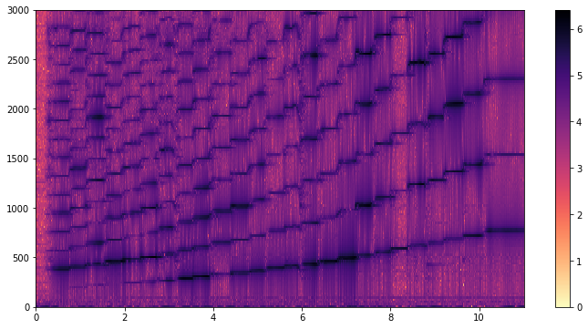

```python
# Time resolution vs frequency resolution tradeoff in window size
x, sr = librosa.load("chromatic2octaves.wav", sr=44100)
win = 2048
hop = 256
S = specgram(x, win, hop, sr)
times = hop*np.arange(S.shape[1])/sr
freqs = np.arange(S.shape[0])*sr/win
S = np.log10(S/np.min(S))
plt.figure(figsize=(12, 6))
plt.imshow(S, cmap='magma_r', extent = (times[0], times[-1], freqs[-1], freqs[0]), aspect='auto', interpolation='none')
plt.ylim([3000, 0])
plt.gca().invert_yaxis()
plt.colorbar()
#plt.xlim([0, 2])
```

In addition to notes changing, we can also see some other neat physical effects in spectrograms like vibrato. Note that if I'm going back and forth by 10hz in my base frequency, I don't have the resolution to see that at a window length of 2048, as the increment between frequencies is more than 21.5hz (as shown in the code below). But since the harmonics are multiples, we do start to see the wiggling in higher frequencies. For instance, for a vibrato of +/-10hz, the 10th harmonic would be +/-100hz. At a resolution of 21.5hz, this is about 10 pixels from top ot bottom in the spectrogram image

```
Frequency increment: 21.533hz
```

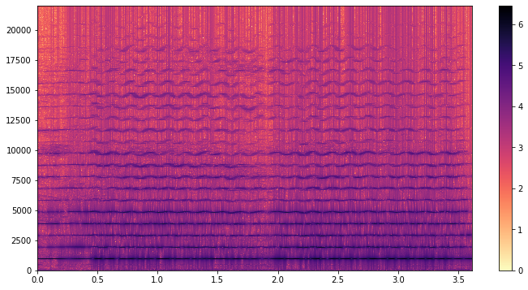

```python
# Time resolution vs frequency resolution tradeoff in window size
x, sr = librosa.load("B5Vibrato.wav", sr=44100)
win = 2048
hop = 256
S = specgram(x, win, hop, sr)
times = hop*np.arange(S.shape[1])/sr
freqs = np.arange(S.shape[0])*sr/win
print("Frequency increment: {:.3f}hz".format(freqs[2]-freqs[1]))
S = np.log10(S/np.min(S))
plt.figure(figsize=(12, 6))
plt.imshow(S, cmap='magma_r', extent = (times[0], times[-1], freqs[-1], freqs[0]), aspect='auto', interpolation='none')
plt.gca().invert_yaxis()
plt.colorbar()
```

```python
ipd.Audio(x, rate=sr)
```

[interactive chart not shown]

```python
10*440*2**(14/12)
```

```
9877.666025122482
```

```
[ 818.26171875  839.79492188  861.328125    882.86132812  904.39453125
  925.92773438  947.4609375   968.99414062  990.52734375 1012.06054688
 1033.59375    1055.12695312 1076.66015625 1098.19335938 1119.7265625
 1141.25976562 1162.79296875 1184.32617188]
```

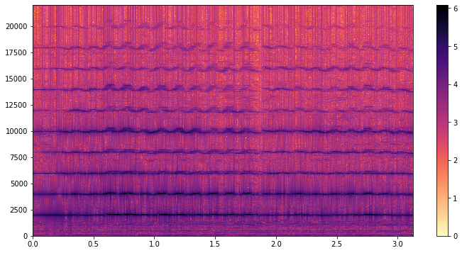

```python
# Time resolution vs frequency resolution tradeoff in window size
x, sr = librosa.load("B6Vibrato.wav", sr=44100)
win = 2048
hop = 256
S = specgram(x, win, hop, sr)
times = hop*np.arange(S.shape[1])/sr
freqs = np.arange(S.shape[0])*sr/win
print(freqs[(freqs > 800)*(freqs < 1200)])
S = np.log10(S/np.min(S))
plt.figure(figsize=(12, 6))
plt.imshow(S, cmap='magma_r', extent = (times[0], times[-1], freqs[-1], freqs[0]), aspect='auto', interpolation='none')
plt.gca().invert_yaxis()
plt.colorbar()
```

```python
ipd.Audio(x, rate=sr)
```

[interactive chart not shown]